# NYC 311 Service Level Agreement Compliance

An Agency-Level Analysis of Resolution Times Against Published Targets, January 2022 – December 2025

Author

Mary Lycke

Published

May 17, 2026

Abstract

This report examines whether New York City agencies resolve 311 requests in accordance with their published Service Level Agreements (SLAs). Analyzing 13.5 million service requests submitted between January 2022 and December 2025, the analysis joins each request to its agency-specific SLA target and compares actual median resolution time against that target. Results identify three operational regimes among NYC agencies: agencies that reliably meet their published commitments, agencies that systematically miss them, and agencies whose data exhibit measurement irregularities that prevent meaningful evaluation. Findings are intended to evaluate whether there is segmented prioritization of issues.

# 1 Overall Question and Specific Question

## 1.1 Overall Question (OQ)

**What factors drive 311 service request response and resolution times, and do they suggest segmented prioritization of issues?**

> *311 receives roughly 3-4 million requests per year across dozens of New York City agencies. If you’ve ever submitted a request yourself, you may be aware that whether or not your issue is resolved is hit or miss. Can we use 311 data to determine if some areas or issues are systematically underserved?*

## 1.2 Specific Question (SQ)

**How do resolution times vary between city agencies compared to Service Level Agreements?**

> *A straightforward way to understand how NYC agencies are performing with address 311 issues is to evaluate agency-level standards and how 311 request resolution times compare to those standards.*

# 2 Data and Methods

This analysis joins two datasets published by NYC Open Data via the Socrata API: the 311 Service Requests dataset (`erm2-nwe9`, ~13.5 million rows over the analysis window) and the 311 Service Level Agreements lookup table (`cs9t-e3x8`, ~1,500 rows). The pipeline is split across three stages: data acquisition, chunked join with compliance calculation, and downstream analysis.

> *Data aquisition pulls the dataset in monthly chunks via the Socrata API, caching each month to disk to avoid a failed connection mid-pull impacting already stored data. The SLA dataset is small enough to pull in a single call. After this, the sla_days column is parsed into numeric hours and each row is tagged as either measurable, not_managed_by_311 or unparseable to preserve the distinction between SLA categories city agencies have mapped to how 311 fields data requests. The chunked join then processes each cached month independently, matching service requests to SLAs on a four-key join for agency, complaint type, descriptior, and secondary descriptor. It then falls back to a three-key join for rows that fail the most granular match, retaining unmatched rows tagged no_match so coverage gaps can be quantified rather than discarded. Compliance is anchored to a fixed reference date, January 1, 2026, so that re-runs produce identifical results, and tickets still open past their SLA are counted as failures rather than dropped from the denominator. Processing month by month keeps peak memory under five gigabytes despite the 13.5 million service requests. Per month outputs are concatenated at the end to produce the joined dataset used for all downstream analysis.*

## 2.1 Stage 1 — Data Acquisition

The code below pulls service requests and the SLA lookup from the Socrata API. It chunks the SR pull one month at a time, caches each month to disk, and retries with exponential backoff on transient failures. The full pull takes 3–5 hours; the chunk-and-cache design means a mid-pipeline failure resumes from the last successful month rather than restarting from January 2022. This chunk is shown for methodology but does not re-execute at render time.

```r
# ---- 0. Packages ----
pkgs <- c("RSocrata", "dplyr", "lubridate", "stringr", "tidyr", "readr", "httr", "purrr")
to_install <- pkgs[!pkgs %in% rownames(installed.packages())]
if (length(to_install)) install.packages(to_install)
invisible(lapply(pkgs, library, character.only = TRUE))

# ---- 1. Config ----
SOCRATA_APP_TOKEN <- Sys.getenv("SOCRATA_APP_TOKEN", unset = "fY0DltbUaGfPenH6P7chzp1yf")
SR_ENDPOINT  <- "https://data.cityofnewyork.us/resource/erm2-nwe9.json"
SLA_ENDPOINT <- "https://data.cityofnewyork.us/resource/cs9t-e3x8.json"
START_DATE <- "2022-01-01T00:00:00.000"
END_DATE   <- "2026-01-01T00:00:00.000"
SAMPLE_ONLY <- FALSE
SAMPLE_LIMIT <- 50000

HTTP_TIMEOUT_SEC <- 600
MAX_RETRIES <- 5
RETRY_BACKOFF_SEC <- 30
CHUNK_BY_MONTH <- TRUE
CACHE_DIR <- "socrata_cache"
dir.create(CACHE_DIR, showWarnings = FALSE)
ANALYSIS_AS_OF <- as.POSIXct("2026-01-01 00:00:00", tz = "UTC")

# Resilient Socrata wrapper with retries and exponential backoff
safe_socrata <- function(url, token, label = url) {
  attempt <- 0
  repeat {
    attempt <- attempt + 1
    result <- tryCatch(
      httr::with_config(
        config = httr::timeout(HTTP_TIMEOUT_SEC),
        read.socrata(url, app_token = token)
      ),
      error = function(e) e
    )
    if (!inherits(result, "error")) return(result)
    if (attempt >= MAX_RETRIES) {
      stop("Failed after ", MAX_RETRIES, " attempts on ", label,
           "\nLast error: ", conditionMessage(result))
    }
    wait <- RETRY_BACKOFF_SEC * (2 ^ (attempt - 1))
    message("  Attempt ", attempt, " failed. Retrying in ", wait, "s...")
    Sys.sleep(wait)
  }
}

# ---- 2. Pull and parse SLA lookup ----
sla_raw <- safe_socrata(SLA_ENDPOINT, SOCRATA_APP_TOKEN, "SLA lookup")

sla <- sla_raw %>%
  mutate(
    sla_num  = as.numeric(str_extract(sla_days, "\\d+\\.?\\d*")),
    sla_unit = str_to_lower(str_extract(sla_days, "[a-zA-Z]+")),
    sla_hours = case_when(
      sla_unit %in% c("hour", "hours") ~ sla_num,
      sla_unit %in% c("day",  "days")  ~ sla_num * 24,
      TRUE                             ~ NA_real_
    ),
    sla_days_numeric = sla_hours / 24,
    sla_status = case_when(
      !is.na(sla_hours) ~ "measurable",
      str_detect(sla_days, regex("not managed", ignore_case = TRUE)) ~ "not_managed_by_311",
      TRUE ~ "unparseable"
    ),
    problem_details    = if_else(is.na(problem_details)    | problem_details    == "", "N/A", problem_details),
    additional_details = if_else(is.na(additional_details) | additional_details == "", "N/A", additional_details)
  )

# ---- 3. Pull Service Requests (chunked by month with disk caching) ----
build_where <- function(start_iso, end_iso) {
  sprintf("created_date >= '%s' AND created_date < '%s'", start_iso, end_iso)
}
build_url <- function(where_clause, limit = NULL) {
  paste0(SR_ENDPOINT, "?$where=", URLencode(where_clause, reserved = TRUE),
         if (!is.null(limit)) paste0("&$limit=", limit) else "")
}

if (SAMPLE_ONLY) {
  sr_url <- build_url(build_where(START_DATE, END_DATE), limit = SAMPLE_LIMIT)
  sr_raw <- safe_socrata(sr_url, SOCRATA_APP_TOKEN, "SR sample")
} else if (CHUNK_BY_MONTH) {
  month_starts <- seq(as.Date("2022-01-01"), as.Date("2025-12-01"), by = "1 month")
  sr_chunks <- vector("list", length(month_starts))
  for (i in seq_along(month_starts)) {
    m_start <- month_starts[i]
    m_end   <- seq(m_start, by = "1 month", length.out = 2)[2]
    tag     <- format(m_start, "%Y-%m")
    cache_file <- file.path(CACHE_DIR, paste0("sr_", tag, ".rds"))
    if (file.exists(cache_file)) {
      sr_chunks[[i]] <- readRDS(cache_file)
      next
    }
    url <- build_url(build_where(
      format(m_start, "%Y-%m-%dT00:00:00.000"),
      format(m_end,   "%Y-%m-%dT00:00:00.000")
    ))
    chunk <- safe_socrata(url, SOCRATA_APP_TOKEN, paste("SR chunk", tag))
    saveRDS(chunk, cache_file)
    sr_chunks[[i]] <- chunk
  }
  sr_raw <- bind_rows(sr_chunks)
} else {
  sr_url <- build_url(build_where(START_DATE, END_DATE))
  sr_raw <- safe_socrata(sr_url, SOCRATA_APP_TOKEN, "full SR pull")
}

write_csv(sla, "sla_lookup_parsed.csv")
```

## 2.2 Stage 2 — Chunked Join and Compliance Calculation

The join is performed month-by-month to keep peak memory below 5 GB on a 16 GB workstation; the full-data version of the prep + join would hold multiple copies of 13.5M rows in memory simultaneously and crash. The join uses a tiered key strategy: a 4-key match on agency, complaint type, descriptor, and additional descriptor for the most granular fit, then a 3-key fallback for SRs whose 4-key combination has no SLA entry, then an unmatched bucket kept in the dataset with `NA` SLA values so coverage can be reported transparently. The `met_sla` flag distinguishes closed-within-SLA, closed-past-SLA, open-and-already-overdue, and not-yet-evaluable cases.

```r
library(dplyr); library(lubridate); library(stringr); library(tidyr); library(readr)

CACHE_DIR_RAW <- "socrata_cache"
CACHE_DIR_PROCESSED <- "processed_cache"
dir.create(CACHE_DIR_PROCESSED, showWarnings = FALSE)
ANALYSIS_AS_OF <- as.POSIXct("2026-01-01 00:00:00", tz = "UTC")

sla <- read_csv("sla_lookup_parsed.csv", show_col_types = FALSE) %>%
  mutate(
    problem_details    = if_else(is.na(problem_details)    | problem_details    == "", "N/A", problem_details),
    additional_details = if_else(is.na(additional_details) | additional_details == "", "N/A", additional_details)
  )

raw_files <- list.files(CACHE_DIR_RAW, pattern = "^sr_\\d{4}-\\d{2}\\.rds$", full.names = TRUE)
raw_files <- sort(raw_files)

process_month <- function(raw_path) {
  tag <- str_extract(basename(raw_path), "\\d{4}-\\d{2}")
  out_path <- file.path(CACHE_DIR_PROCESSED, paste0("sr_with_sla_", tag, ".rds"))
  if (file.exists(out_path)) return(invisible(NULL))

  sr_raw <- readRDS(raw_path)
  sr <- sr_raw %>%
    mutate(
      created_date = ymd_hms(created_date, quiet = TRUE),
      closed_date  = ymd_hms(closed_date,  quiet = TRUE),
      descriptor   = if_else(is.na(descriptor)   | descriptor   == "", "N/A", descriptor),
      descriptor_2 = if_else(is.na(descriptor_2) | descriptor_2 == "", "N/A", descriptor_2)
    )
  rm(sr_raw); gc(verbose = FALSE)

  # 4-key match (most granular)
  join4 <- sr %>%
    inner_join(
      sla %>% select(agency, problem, problem_details, additional_details,
                     sla_days, sla_hours, sla_days_numeric, sla_status),
      by = c("agency_name" = "agency",
             "complaint_type" = "problem",
             "descriptor" = "problem_details",
             "descriptor_2" = "additional_details")
    ) %>% mutate(sla_match_level = "agency+type+desc+addl")

  matched_ids <- join4$unique_key

  # 3-key fallback
  join3 <- sr %>%
    filter(!unique_key %in% matched_ids) %>%
    inner_join(
      sla %>%
        select(agency, problem, problem_details, sla_days, sla_hours, sla_days_numeric, sla_status) %>%
        distinct(agency, problem, problem_details, .keep_all = TRUE),
      by = c("agency_name" = "agency",
             "complaint_type" = "problem",
             "descriptor" = "problem_details")
    ) %>% mutate(sla_match_level = "agency+type+desc")

  matched_ids <- c(matched_ids, join3$unique_key)

  unmatched <- sr %>%
    filter(!unique_key %in% matched_ids) %>%
    mutate(sla_days = NA_character_, sla_hours = NA_real_,
           sla_days_numeric = NA_real_, sla_status = "no_match",
           sla_match_level = "unmatched")

  rm(sr); gc(verbose = FALSE)

  sr_with_sla_month <- bind_rows(join4, join3, unmatched)
  rm(join4, join3, unmatched); gc(verbose = FALSE)

  # Compliance metric
  sr_with_sla_month <- sr_with_sla_month %>%
    mutate(
      resolution_hours = as.numeric(difftime(closed_date, created_date, units = "hours")),
      met_sla = case_when(
        sla_status %in% c("not_managed_by_311", "no_match", "unparseable") ~ NA,
        is.na(sla_hours) ~ NA,
        is.na(closed_date) & (as.numeric(difftime(ANALYSIS_AS_OF, created_date, units = "hours")) > sla_hours) ~ FALSE,
        is.na(closed_date) ~ NA,
        resolution_hours <= sla_hours ~ TRUE,
        TRUE ~ FALSE
      )
    )

  saveRDS(sr_with_sla_month, out_path)
  rm(sr_with_sla_month); gc(verbose = FALSE)
  invisible(NULL)
}

for (f in raw_files) process_month(f)

# Concatenate per-month outputs into final dataset
processed_files <- list.files(CACHE_DIR_PROCESSED,
                              pattern = "^sr_with_sla_\\d{4}-\\d{2}\\.rds$",
                              full.names = TRUE) %>% sort()
sr_with_sla <- lapply(processed_files, readRDS) %>% bind_rows()
saveRDS(sr_with_sla, "sr_with_sla.rds")
```

## 2.3 Stage 3 — Loading the Joined Dataset

This chunk loads the joined dataset produced by Stages 1 and 2. The rendering session reads it from disk; everything downstream operates on the in-memory `sr_with_sla` object.

```r
library(dplyr)
library(ggplot2)
library(scales)
library(stringr)
library(knitr)
library(kableExtra)
library(here)

# sr_with_sla.rds is included in the project submission.
# Stages 1 and 2 (eval: false) document the original pull
# but do not re-execute at render time.
sr_with_sla <- readRDS("sr_with_sla.rds")
```

## 2.4 Data Quality and Coverage

> *Of 13.5 million service requests in the analysis window, 8.4 million (62%) joined to a measurable SLA target. The 5.0 million unmatched rows are not evenly distributed: roughly 90% fall in complaint types with no published SLA at all, dominated by HPD habitability complaints (heat/hot water, unsanitary conditions, plumbing) and DHS shelter intake, while the remaining 10% reflect taxonomy mismatches between agency intake codes and SLA category names. The coverage gap is therefore a structural feature of the SLA framework rather than a join failure, and it is not random with respect to agency or complaint severity. Among the rows that do join cleanly, exploratory analysis surfaced additional irregularities in how compliance is recorded; those patterns are examined in the following section.*

```r
sr_with_sla %>%
  count(sla_status, sla_match_level, name = "n_requests") %>%
  arrange(desc(n_requests)) %>%
  mutate(pct = scales::percent(n_requests / sum(n_requests), accuracy = 0.1)) %>%
  kable(
    col.names = c("SLA Status", "Match Level", "Requests", "% of Total"),
    format.args = list(big.mark = ",")
  ) %>%
  kable_styling(bootstrap_options = c("striped", "hover", "condensed"),
                full_width = FALSE, position = "left")
```

Table 1: SLA Match Coverage Across All Service Requests, 2022–2025

| SLA Status | Match Level | Requests | % of Total |
| --- | --- | --- | --- |
| measurable | agency+type+desc+addl | 8,225,933 | 60.9% |
| no_match | unmatched | 4,950,406 | 36.7% |
| measurable | agency+type+desc | 204,564 | 1.5% |
| not_managed_by_311 | agency+type+desc+addl | 125,500 | 0.9% |
| not_managed_by_311 | agency+type+desc | 13 | 0.0% |

# 3 Exploratory Data Analysis

```r
agency_metrics <- sr_with_sla %>%
  filter(sla_status == "measurable",
         !is.na(sla_hours), sla_hours > 0) %>%
  group_by(agency_name) %>%
  summarise(
    n_requests            = n(),
    n_closed              = sum(!is.na(resolution_hours) & resolution_hours >= 0),
    pct_closed            = n_closed / n_requests,
    mean_resolution_hrs   = mean(resolution_hours[!is.na(resolution_hours) & resolution_hours >= 0]),
    median_resolution_hrs = median(resolution_hours[!is.na(resolution_hours) & resolution_hours >= 0]),
    median_sla_hrs        = median(sla_hours),
    pct_met_sla           = mean(met_sla, na.rm = TRUE),
    .groups = "drop"
  ) %>%
  filter(n_requests >= 1000) %>%
  arrange(desc(n_requests))

agency_metrics %>%
  mutate(
    n_requests            = format(n_requests, big.mark = ","),
    n_closed              = format(n_closed, big.mark = ","),
    pct_closed            = scales::percent(pct_closed, accuracy = 0.1),
    mean_resolution_hrs   = sprintf("%.1f", mean_resolution_hrs),
    median_resolution_hrs = sprintf("%.1f", median_resolution_hrs),
    median_sla_hrs        = sprintf("%.1f", median_sla_hrs),
    pct_met_sla           = scales::percent(pct_met_sla, accuracy = 0.1)
  ) %>%
  kable(
    col.names = c("Agency", "Requests", "Closed", "% Closed",
                  "Mean Hrs", "Median Hrs", "Median SLA Hrs", "% Met SLA"),
    align = c("l", "r", "r", "r", "r", "r", "r", "r")
  ) %>%
  kable_styling(bootstrap_options = c("striped", "hover", "condensed"),
                full_width = FALSE, font_size = 12) %>%
  scroll_box(width = "100%")
```

Table 2: Agency-Level Resolution Time Metrics, January 2022 – December 2025

| Agency | Requests | Closed | % Closed | Mean Hrs | Median Hrs | Median SLA Hrs | % Met SLA |
| --- | --- | --- | --- | --- | --- | --- | --- |
| New York City Police Department | 6,040,983 | 6,040,364 | 100.0% | 3.7 | 1.0 | 8.0 | 93.9% |
| Department of Sanitation | 838,422 | 830,631 | 99.1% | 134.8 | 53.3 | 120.0 | 69.8% |
| Department of Parks and Recreation | 486,259 | 431,012 | 88.6% | 3816.6 | 638.9 | 192.0 | 34.0% |
| Department of Transportation | 354,485 | 354,178 | 99.9% | 299.3 | 123.7 | 336.0 | 84.7% |
| Department of Health and Mental Hygiene | 328,858 | 303,433 | 92.3% | 2281.8 | 16.4 | 720.0 | 65.8% |
| Economic Development Corporation | 134,585 | 100,975 | 75.0% | 5034.0 | 1111.2 | 240.0 | 1.6% |
| Taxi and Limousine Commission | 132,282 | 119,161 | 90.1% | 1621.6 | 1357.8 | 336.0 | 23.7% |
| Department of Consumer and Worker Protection | 62,224 | 58,596 | 94.2% | 329.3 | 66.3 | 96.0 | 56.5% |
| Department of Homeless Services | 29,720 | 29,615 | 99.6% | 30.7 | 5.5 | 1.0 | 20.9% |
| Department of Housing Preservation and Development | 12,357 | 40 | 0.3% | 381.1 | 397.2 | 72.0 | 0.0% |
| Department of Education | 6,095 | 5,893 | 96.7% | 1490.1 | 377.3 | 168.0 | 36.6% |
| Department of Environmental Protection | 3,195 | 3,129 | 97.9% | 21.8 | 8.0 | 6.0 | 64.1% |

```r
sla_targets <- sr_with_sla %>%
  filter(sla_status == "measurable", !is.na(sla_hours), sla_hours > 0) %>%
  count(agency_name, complaint_type, sla_days, sla_hours, name = "n_requests") %>%
  group_by(agency_name) %>%
  arrange(desc(n_requests), .by_group = TRUE) %>%
  slice_head(n = 6) %>%
  mutate(rank = row_number()) %>%
  ungroup() %>%
  arrange(agency_name, rank)

sla_targets %>%
  select(agency_name, rank, complaint_type, sla_days, n_requests) %>%
  mutate(n_requests = format(n_requests, big.mark = ",")) %>%
  kable(
    col.names = c("Agency", "Rank", "Complaint Type", "SLA Target", "Requests"),
    align = c("l", "c", "l", "l", "r")
  ) %>%
  kable_styling(bootstrap_options = c("striped", "hover", "condensed"),
                full_width = FALSE, font_size = 11) %>%
  collapse_rows(columns = 1, valign = "top") %>%
  scroll_box(width = "100%", height = "500px")
```

Table 3: Top 6 Most Common SLA Targets per Agency, by Request Volume

| Agency | Rank | Complaint Type | SLA Target | Requests |
| --- | --- | --- | --- | --- |
| Department for the Aging | 1 | Home Delivered Meal - Missed Delivery | 3 days | 26 |
| Department of Buildings | 1 | Water Drainage | 60 days | 136 |
|  | 2 | Unstable Building | 2 days | 85 |
|  | 3 | Boiler | 40 days | 41 |
|  | 4 | Building Condition | 60 days | 20 |
|  | 5 | DOB Posted Notice or Order | 2 days | 5 |
| Department of Consumer and Worker Protection | 1 | Consumer Complaint | 4 days | 62,224 |
| Department of Education | 1 | School Maintenance | 7 days | 4,608 |
|  | 2 | School Maintenance | 3 days | 1,487 |
| Department of Environmental Protection | 1 | Sewer Maintenance | 6 hours | 1,550 |
|  | 2 | Sewer Maintenance | 1 day | 673 |
|  | 3 | Sewer Maintenance | 6 days | 571 |
|  | 4 | Water Maintenance | 16 hours | 244 |
|  | 5 | Water Maintenance | 6 hours | 138 |
|  | 6 | Sewer Maintenance | 8 hours | 15 |
| Department of Health and Mental Hygiene | 1 | Rodent | 30 days | 153,907 |
|  | 2 | Food Establishment | 37 days | 46,635 |
|  | 3 | Mobile Food Vendor | 37 days | 18,755 |
|  | 4 | Indoor Air Quality | 30 days | 16,402 |
|  | 5 | Indoor Air Quality | 45 days | 13,280 |
|  | 6 | Food Poisoning | 14 days | 11,665 |
| Department of Homeless Services | 1 | Homeless Person Assistance | 1 hour | 20,855 |
|  | 2 | Homeless Person Assistance | 4 hours | 8,865 |
| Department of Housing Preservation and Development | 1 | Water Leak | 3 days | 1,785 |
|  | 2 | Water Leak | 8 days | 1,291 |
|  | 3 | Unsanitary Condition | 3 days | 1,259 |
|  | 4 | Paint/Plaster | 8 days | 1,212 |
|  | 5 | Door/Window | 3 days | 986 |
|  | 6 | Plumbing | 3 days | 916 |
| Department of Parks and Recreation | 1 | New Tree Request | 7 days | 63,739 |
|  | 2 | Overgrown Tree/Branches | 30 days | 62,303 |
|  | 3 | Damaged Tree | 4 days | 61,572 |
|  | 4 | Maintenance or Facility | 14 days | 41,641 |
|  | 5 | Maintenance or Facility | 3 days | 38,328 |
|  | 6 | Dead/Dying Tree | 7 days | 37,918 |
| Department of Sanitation | 1 | Dirty Condition | 7 days | 203,344 |
|  | 2 | Missed Collection | 5 days | 187,281 |
|  | 3 | Illegal Dumping | 5 days | 121,332 |
|  | 4 | Obstruction | 5 days | 63,604 |
|  | 5 | Residential Disposal Complaint | 7 days | 44,187 |
|  | 6 | Dead Animal | 2 days | 40,844 |
| Department of Transportation | 1 | Street Condition | 10 days | 89,697 |
|  | 2 | Sidewalk Condition | 30 days | 75,147 |
|  | 3 | Curb Condition | 30 days | 18,743 |
|  | 4 | Street Sign - Damaged | 14 days | 15,264 |
|  | 5 | Sidewalk Condition | 10 days | 14,252 |
|  | 6 | Outdoor Dining | 10 days | 13,554 |
| Economic Development Corporation | 1 | Noise - Helicopter | 10 days | 134,585 |
| New York City Police Department | 1 | Illegal Parking | 8 hours | 1,965,725 |
|  | 2 | Noise - Residential | 8 hours | 1,518,145 |
|  | 3 | Blocked Driveway | 8 hours | 665,215 |
|  | 4 | Noise - Street/Sidewalk | 8 hours | 636,537 |
|  | 5 | Abandoned Vehicle | 8 hours | 265,652 |
|  | 6 | Noise - Commercial | 8 hours | 261,193 |
| Office of Technology and Innovation | 1 | LinkNYC | 30 days | 662 |
|  | 2 | Public Payphone Complaint | 30 days | 57 |
| Taxi and Limousine Commission | 1 | For Hire Vehicle Complaint | 14 days | 73,793 |
|  | 2 | Taxi Complaint | 14 days | 30,039 |
|  | 3 | Lost Property | 7 days | 27,008 |
|  | 4 | Green Taxi Complaint | 14 days | 1,406 |
|  | 5 | FHV Licensee Complaint | 14 days | 36 |

# 4 Analysis: Agency Resolution Times Against SLA

The core analysis computes, for each agency, the ratio of median actual resolution time to median published SLA target. A ratio of 1 means the agency closes its typical request exactly at its committed window; a ratio of 0.5 means twice as fast as committed; a ratio of 2 means twice as slow.

## 4.1 Computing the Agency Ratio

```r
agency_ratio <- sr_with_sla %>%
  filter(sla_status == "measurable",
         !is.na(sla_hours),
         sla_hours > 0) %>%
  group_by(agency) %>%
  summarise(
    n_total           = n(),
    n_closed          = sum(!is.na(resolution_hours) & resolution_hours >= 0),
    pct_closed        = n_closed / n_total,
    median_resolution_hrs = median(resolution_hours[!is.na(resolution_hours) & resolution_hours >= 0]),
    median_sla_hrs    = median(sla_hours),
    ratio             = median_resolution_hrs / median_sla_hrs,
    compliance_closed = mean(met_sla[!is.na(resolution_hours) & resolution_hours >= 0], na.rm = TRUE),
    compliance_all    = mean(met_sla, na.rm = TRUE),
    .groups = "drop"
  ) %>%
  filter(n_total >= 100) %>%
  arrange(ratio)
```

## 4.2 Headline Figure — Diverging Bar Chart

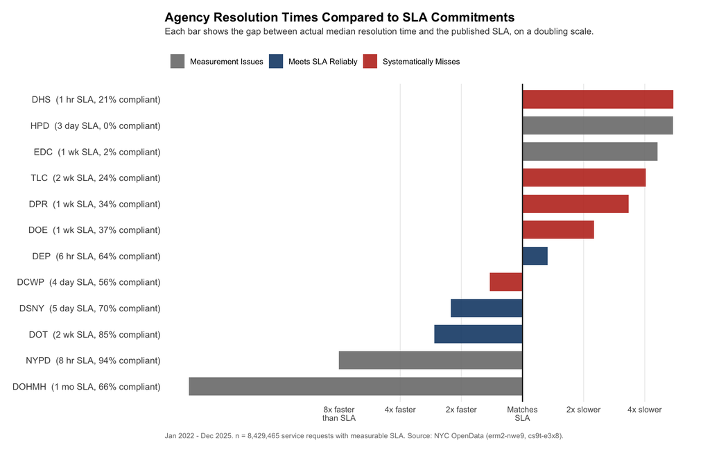

Figure 1: Each agency’s bar shows the gap between actual median resolution time and the published SLA target on a doubling (log₂) scale. Bars left of center beat their SLA; bars right of center miss it.

```r
plot_data <- agency_ratio %>%
  filter(n_total >= 1000, ratio > 0) %>%
  mutate(
    log2_ratio = log2(ratio),
    classification = case_when(
      agency %in% c("NYPD", "DOHMH", "EDC", "HPD") ~ "Measurement Issues",
      compliance_all >= 0.60                       ~ "Meets SLA Reliably",
      TRUE                                         ~ "Systematically Misses"
    ),
    sla_label = case_when(
      median_sla_hrs < 24       ~ paste0(round(median_sla_hrs), " hr"),
      median_sla_hrs < 24 * 7   ~ paste0(round(median_sla_hrs / 24), " day"),
      median_sla_hrs < 24 * 30  ~ paste0(round(median_sla_hrs / (24 * 7)), " wk"),
      median_sla_hrs < 24 * 365 ~ paste0(round(median_sla_hrs / (24 * 30)), " mo"),
      TRUE                      ~ paste0(round(median_sla_hrs / (24 * 365), 1), " yr")
    ),
    y_label = sprintf("%s  (%s SLA, %.0f%% compliant)",
                      agency, sla_label, compliance_all * 100)
  ) %>%
  arrange(log2_ratio)

plot_data$y_label <- factor(plot_data$y_label, levels = plot_data$y_label)

group_colors <- c(
  "Meets SLA Reliably"    = "#1f4e79",
  "Systematically Misses" = "#c0392b",
  "Measurement Issues"    = "#7f7f7f"
)

ggplot(plot_data, aes(y = y_label, x = log2_ratio, fill = classification)) +
  geom_vline(xintercept = c(-2, -1, 1, 2), color = "#eeeeee", linewidth = 0.5) +
  geom_col(width = 0.7, alpha = 0.92) +
  geom_vline(xintercept = 0, color = "#222222", linewidth = 0.6) +
  scale_x_continuous(
    breaks = c(-3, -2, -1, 0, 1, 2, 3),
    labels = c("8x faster\nthan SLA", "4x faster", "2x faster",
               "Matches\nSLA",
               "2x slower", "4x slower", "8x slower\nthan SLA"),
    expand = expansion(mult = c(0.05, 0.05))
  ) +
  scale_fill_manual(values = group_colors, name = NULL) +
  labs(
    title    = "Agency Resolution Times Compared to SLA Commitments",
    subtitle = "Each bar shows the gap between actual median resolution time and the published SLA, on a doubling scale.",
    x = NULL, y = NULL,
    caption = paste0(
      "Jan 2022 - Dec 2025. n = ", format(sum(plot_data$n_total), big.mark = ","),
      " service requests with measurable SLA. Source: NYC OpenData (erm2-nwe9, cs9t-e3x8)."
    )
  ) +
  theme_minimal(base_size = 11) +
  theme(
    plot.title         = element_text(face = "bold", size = 14, margin = margin(b = 4)),
    plot.subtitle      = element_text(color = "#444444", size = 10, margin = margin(b = 14)),
    plot.caption       = element_text(color = "#777777", size = 8, hjust = 0, margin = margin(t = 12)),
    legend.position    = "top",
    legend.justification = "left",
    panel.grid.minor   = element_blank(),
    panel.grid.major.y = element_blank(),
    panel.grid.major.x = element_blank(),
    axis.text.y        = element_text(size = 10, hjust = 1),
    axis.text.x        = element_text(size = 9, color = "#555555", lineheight = 0.85),
    plot.margin        = margin(14, 14, 14, 14)
  )
```

> *This chart shows how NYC agencies’ median resolution time compares to their SLA commitments, as well as the compliance rate for each agency. A 60% compliance rate was used as a baseline for determining if agencies reliably met their SLA commitments.*

## 4.3 Bootstrap Confidence Intervals — Agency Compliance Rates

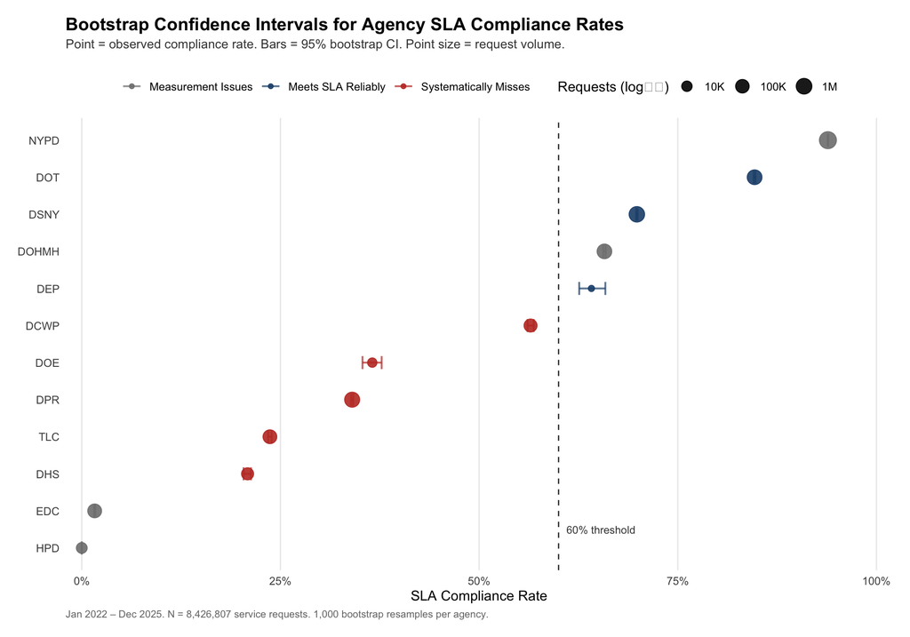

Figure 2: Bootstrap 95% confidence intervals for agency SLA compliance rates. Agencies with wider intervals have fewer tickets and therefore less certain estimates. Agencies flagged for measurement issues are shown in grey.

```r
library(purrr)

set.seed(42)
N_BOOT <- 1000

bootstrap_ci <- sr_with_sla %>%
  filter(sla_status == "measurable",
         !is.na(sla_hours),
         sla_hours > 0,
         !is.na(met_sla)) %>%
  group_by(agency) %>%
  filter(n() >= 1000) %>%
  summarise(
    n_total      = n(),
    observed_rate = mean(met_sla, na.rm = TRUE),
    boot_ci = list({
      x <- met_sla
      boot_means <- replicate(N_BOOT, mean(sample(x, length(x), replace = TRUE), na.rm = TRUE))
      quantile(boot_means, c(0.025, 0.975))
    }),
    .groups = "drop"
  ) %>%
  mutate(
    ci_lo = map_dbl(boot_ci, 1),
    ci_hi = map_dbl(boot_ci, 2),
    classification = case_when(
      agency %in% c("NYPD", "DOHMH", "EDC", "HPD") ~ "Measurement Issues",
      observed_rate >= 0.60                         ~ "Meets SLA Reliably",
      TRUE                                          ~ "Systematically Misses"
    )
  ) %>%
  arrange(observed_rate)

boot_colors <- c(
  "Meets SLA Reliably"    = "#1f4e79",
  "Systematically Misses" = "#c0392b",
  "Measurement Issues"    = "#7f7f7f"
)

ggplot(bootstrap_ci,
       aes(x = observed_rate,
           y = reorder(agency, observed_rate),
           color = classification)) +
  geom_vline(xintercept = 0.60, linetype = "dashed",
             color = "#444444", linewidth = 0.5) +
  geom_errorbarh(aes(xmin = ci_lo, xmax = ci_hi),
                 height = 0.35, linewidth = 0.7, alpha = 0.7) +
  geom_point(aes(size = log10(n_total)), alpha = 0.9) +
  scale_x_continuous(labels = scales::percent_format(accuracy = 1),
                     limits = c(0, 1),
                     expand = expansion(mult = c(0.02, 0.02))) +
  scale_color_manual(values = boot_colors, name = NULL) +
  scale_size_continuous(name = "Requests (log₁₀)",
                        range = c(2, 6),
                        breaks = c(3, 4, 5, 6),
                        labels = c("1K", "10K", "100K", "1M")) +
  annotate("text", x = 0.61, y = 1.5,
           label = "60% threshold", hjust = 0,
           size = 3, color = "#444444") +
  labs(
    title    = "Bootstrap Confidence Intervals for Agency SLA Compliance Rates",
    subtitle = "Point = observed compliance rate. Bars = 95% bootstrap CI. Point size = request volume.",
    x = "SLA Compliance Rate", y = NULL,
    caption = paste0("Jan 2022 – Dec 2025. N = ",
                     format(sum(bootstrap_ci$n_total), big.mark = ","),
                     " service requests. 1,000 bootstrap resamples per agency.")
  ) +
  theme_minimal(base_size = 11) +
  theme(
    plot.title       = element_text(face = "bold", size = 14, margin = margin(b = 4)),
    plot.subtitle    = element_text(color = "#444444", size = 10, margin = margin(b = 14)),
    plot.caption     = element_text(color = "#777777", size = 8, hjust = 0),
    legend.position  = "top",
    panel.grid.minor = element_blank(),
    panel.grid.major.y = element_blank(),
    plot.margin      = margin(14, 14, 14, 14)
  )
```

> *To assess the statistical certainty of agency compliance rates, bootstrap confidence intervals (1,000 samples) were computed for each agency. High-volume agencies like NYPD and DOT show very narrow intervals, while smaller agencies show wider uncertainty bands, reflecting the difference in sample size rather than true performance variability.*

## 4.4 Interactive Dashboard — Explore Agency Performance

```r
library(plotly)
library(DT)
library(crosstalk)

# ---- Prepare shared data ----
dashboard_data <- agency_ratio %>%
  filter(n_total >= 1000, ratio > 0) %>%
  mutate(
    log2_ratio = log2(ratio),
    classification = case_when(
      agency %in% c("NYPD", "DOHMH", "EDC", "HPD") ~ "Measurement Issues",
      compliance_all >= 0.60                        ~ "Meets SLA Reliably",
      TRUE                                          ~ "Systematically Misses"
    ),
    sla_label = case_when(
      median_sla_hrs < 24       ~ paste0(round(median_sla_hrs), " hr"),
      median_sla_hrs < 24 * 7   ~ paste0(round(median_sla_hrs / 24), " day"),
      median_sla_hrs < 24 * 30  ~ paste0(round(median_sla_hrs / (24 * 7)), " wk"),
      median_sla_hrs < 24 * 365 ~ paste0(round(median_sla_hrs / (24 * 30)), " mo"),
      TRUE                      ~ paste0(round(median_sla_hrs / (24 * 365), 1), " yr")
    ),
    compliance_pct  = scales::percent(compliance_all, accuracy = 0.1),
    ratio_label     = sprintf("%.2fx", ratio),
    tooltip_text    = paste0(
      "<b>", agency, "</b><br>",
      "Classification: ", classification, "<br>",
      "Median Resolution: ", sprintf("%.1f", median_resolution_hrs), " hrs<br>",
      "Median SLA: ", sla_label, "<br>",
      "Ratio: ", ratio_label, "<br>",
      "Compliance: ", compliance_pct, "<br>",
      "Requests: ", format(n_total, big.mark = ",")
    )
  ) %>%
  arrange(log2_ratio)

# Shared data object for crosstalk
shared_agencies <- SharedData$new(dashboard_data, key = ~agency)

# ---- Color mapping ----
color_map <- c(
  "Meets SLA Reliably"    = "#1f4e79",
  "Systematically Misses" = "#c0392b",
  "Measurement Issues"    = "#7f7f7f"
)

# ---- Plotly diverging bar chart ----
p <- shared_agencies %>%
  plot_ly(
    x           = ~log2_ratio,
    y           = ~reorder(agency, -log2_ratio),
    color       = ~classification,
    colors      = color_map,
    type        = "bar",
    orientation = "h",
    text        = ~tooltip_text,
    hoverinfo   = "text",
    marker      = list(opacity = 0.9)
  ) %>%
  layout(
    title = list(
      text = "<b>Agency Resolution Times vs SLA Commitments</b>",
      font = list(size = 14)
    ),
    xaxis = list(
      title         = "",
      tickvals      = c(-3, -2, -1, 0, 1, 2, 3),
      ticktext      = c("8x faster", "4x faster", "2x faster",
                        "Matches SLA",
                        "2x slower", "4x slower", "8x slower"),
      zeroline      = TRUE,
      zerolinecolor = "#222222",
      zerolinewidth = 1.5,
      gridcolor     = "#eeeeee"
    ),
    yaxis  = list(title = "", tickfont = list(size = 10)),
    legend = list(orientation = "h", x = 0, y = 1.08),
    margin = list(l = 120, r = 20, t = 60, b = 40),
    plot_bgcolor  = "white",
    paper_bgcolor = "white",
    bargap = 0.3
  ) %>%
  highlight(on = "plotly_click", off = "plotly_doubleclick",
            persistent = TRUE, opacityDim = 0.3)

# ---- DT filterable table ----
tbl <- shared_agencies %>%
  datatable(
    selection  = "multiple",
    extensions = "Scroller",
    rownames   = FALSE,
    colnames   = c("Agency", "Requests", "Closed", "% Closed",
                   "Median Res Hrs", "Median SLA Hrs", "Ratio",
                   "Compliance (Closed)", "Compliance (All)", "Classification"),
    options = list(
      dom        = "fti",
      scrollY    = 250,
      scroller   = TRUE,
      pageLength = 20,
      columnDefs = list(
        list(targets = c(1, 2),
             render  = JS("function(data) { return data.toLocaleString(); }")),
        list(targets = c(3, 7, 8),
             render  = JS("function(data) { return (data * 100).toFixed(1) + '%'; }")),
        list(targets = c(4, 5),
             render  = JS("function(data) { return parseFloat(data).toFixed(1); }")),
        list(targets = 6,
             render  = JS("function(data) { return parseFloat(data).toFixed(3); }"))
      )
    )
  ) %>%
  formatStyle(
    "classification",
    backgroundColor = styleEqual(
      c("Meets SLA Reliably", "Systematically Misses", "Measurement Issues"),
      c("#d6e8f7",            "#fde8e6",               "#f0f0f0")
    )
  )

# ---- Lay out side by side ----
bscols(
  widths = c(7, 5),
  p,
  tbl
)
```

[interactive chart not shown]

Interactive Agency SLA Dashboard — select agencies in the table to highlight them in the chart.

> *The dashboard below links the diverging bar chart to a filterable table. Click a bar to highlight that agency in the chart, or search and select rows in the table to highlight them in the chart. Hold Shift to select multiple agencies. Double-click to reset.*

## 4.5 Flagging Anomalous Agencies

Some agencies show resolution-time patterns that suggest measurement irregularities rather than true performance: median resolution under 25% of SLA (suspiciously fast — likely auto-close behavior), 0% compliance among closed tickets (resolution-time logging appears broken), or ≥98% compliance (likely a closure convention rather than genuine performance).

```r
flagged <- agency_ratio %>%
  filter(ratio < 0.25 | compliance_closed == 0 | compliance_closed >= 0.98 |
         compliance_all == 0)

flagged %>%
  mutate(
    n_total           = format(n_total, big.mark = ","),
    pct_closed        = scales::percent(pct_closed, accuracy = 0.1),
    median_resolution_hrs = sprintf("%.2f", median_resolution_hrs),
    median_sla_hrs    = sprintf("%.1f", median_sla_hrs),
    ratio             = sprintf("%.3f", ratio),
    compliance_closed = scales::percent(compliance_closed, accuracy = 0.1),
    compliance_all    = scales::percent(compliance_all, accuracy = 0.1)
  ) %>%
  select(agency, n_total, pct_closed, median_resolution_hrs, median_sla_hrs,
         ratio, compliance_closed, compliance_all) %>%
  kable(
    col.names = c("Agency", "Requests", "% Closed", "Median Res Hrs",
                  "Median SLA Hrs", "Ratio", "% Met (Closed)", "% Met (All)"),
    align = c("l", "r", "r", "r", "r", "r", "r", "r")
  ) %>%
  kable_styling(bootstrap_options = c("striped", "hover", "condensed"),
                full_width = FALSE, font_size = 11)
```

Table 4: Agencies Flagged for Measurement Irregularities

| Agency | Requests | % Closed | Median Res Hrs | Median SLA Hrs | Ratio | % Met (Closed) | % Met (All) |
| --- | --- | --- | --- | --- | --- | --- | --- |
| DOHMH | 328,858 | 92.3% | 16.42 | 720.0 | 0.023 | 71.3% | 65.8% |
| NYPD | 6,040,983 | 100.0% | 1.00 | 8.0 | 0.125 | 93.9% | 93.9% |
| HPD | 12,357 | 0.3% | 397.17 | 72.0 | 5.516 | 0.0% | 0.0% |
| DOB | 287 | 0.0% | NA | 1440.0 | NA | NA | 0.0% |

## 4.6 Drill-Down — A Closer Look at NYPD

```r
target_agency <- "NYPD"

agency_breakdown <- sr_with_sla %>%
  filter(sla_status == "measurable",
         agency == target_agency,
         !is.na(sla_hours),
         sla_hours > 0) %>%
  group_by(complaint_type) %>%
  summarise(
    n_total           = n(),
    n_closed          = sum(!is.na(resolution_hours) & resolution_hours >= 0),
    pct_closed        = n_closed / n_total,
    median_resolution_hrs = median(resolution_hours[!is.na(resolution_hours) & resolution_hours >= 0]),
    p25_resolution_hrs    = quantile(resolution_hours[!is.na(resolution_hours) & resolution_hours >= 0], 0.25, na.rm = TRUE),
    p75_resolution_hrs    = quantile(resolution_hours[!is.na(resolution_hours) & resolution_hours >= 0], 0.75, na.rm = TRUE),
    median_sla_hrs    = median(sla_hours),
    ratio             = median_resolution_hrs / median_sla_hrs,
    compliance_closed = mean(met_sla[!is.na(resolution_hours) & resolution_hours >= 0], na.rm = TRUE),
    compliance_all    = mean(met_sla, na.rm = TRUE),
    .groups = "drop"
  ) %>%
  filter(n_total >= 30) %>%
  arrange(ratio)

agency_breakdown %>%
  mutate(
    n_total           = format(n_total, big.mark = ","),
    pct_closed        = scales::percent(pct_closed, accuracy = 0.1),
    median_resolution_hrs = sprintf("%.2f", median_resolution_hrs),
    median_sla_hrs    = sprintf("%.1f", median_sla_hrs),
    ratio             = sprintf("%.3f", ratio),
    compliance_all    = scales::percent(compliance_all, accuracy = 0.1)
  ) %>%
  select(complaint_type, n_total, pct_closed,
         median_resolution_hrs, median_sla_hrs, ratio, compliance_all) %>%
  kable(
    col.names = c("Complaint Type", "Requests", "% Closed",
                  "Median Res Hrs", "Median SLA Hrs", "Ratio", "% Met SLA"),
    align = c("l", "r", "r", "r", "r", "r", "r")
  ) %>%
  kable_styling(bootstrap_options = c("striped", "hover", "condensed"),
                full_width = FALSE, font_size = 11) %>%
  scroll_box(width = "100%", height = "400px")
```

Table 5: NYPD Resolution-Time Performance by Complaint Type

| Complaint Type | Requests | % Closed | Median Res Hrs | Median SLA Hrs | Ratio | % Met SLA |
| --- | --- | --- | --- | --- | --- | --- |
| Bike/Roller/Skate Chronic | 13,474 | 100.0% | 0.40 | 8.0 | 0.051 | 97.8% |
| Drug Activity | 77,406 | 100.0% | 0.41 | 8.0 | 0.051 | 98.3% |
| Noise - House of Worship | 7,118 | 100.0% | 0.42 | 8.0 | 0.053 | 98.9% |
| Traffic | 32,858 | 100.0% | 0.58 | 8.0 | 0.072 | 97.3% |
| Squeegee | 138 | 100.0% | 0.58 | 8.0 | 0.072 | 97.1% |
| Illegal Fireworks | 41,559 | 100.0% | 0.60 | 8.0 | 0.075 | 98.7% |
| Noise - Park | 34,980 | 100.0% | 0.61 | 8.0 | 0.076 | 98.0% |
| Disorderly Youth | 1,412 | 100.0% | 0.61 | 8.0 | 0.077 | 96.5% |
| Noise - Commercial | 261,193 | 100.0% | 0.65 | 8.0 | 0.081 | 98.3% |
| Noise - Street/Sidewalk | 636,537 | 100.0% | 0.70 | 8.0 | 0.087 | 97.7% |
| Noise - Vehicle | 208,000 | 100.0% | 0.74 | 8.0 | 0.092 | 97.3% |
| Non-Emergency Police Matter | 86,374 | 100.0% | 0.75 | 8.0 | 0.094 | 95.9% |
| Graffiti | 6,761 | 100.0% | 0.83 | 8.0 | 0.104 | 96.6% |
| Drinking | 15,541 | 100.0% | 0.89 | 8.0 | 0.112 | 96.4% |
| Urinating in Public | 4,346 | 100.0% | 0.90 | 8.0 | 0.113 | 96.5% |
| Noise - Residential | 1,518,145 | 100.0% | 0.92 | 8.0 | 0.115 | 91.9% |
| Posting Advertisement | 470 | 100.0% | 1.05 | 8.0 | 0.131 | 94.9% |
| Illegal Parking | 1,965,725 | 100.0% | 1.21 | 8.0 | 0.152 | 93.8% |
| Animal-Abuse | 35,604 | 100.0% | 1.32 | 8.0 | 0.166 | 91.8% |
| Panhandling | 38,706 | 100.0% | 0.70 | 4.0 | 0.175 | 91.6% |
| Blocked Driveway | 665,215 | 100.0% | 1.44 | 8.0 | 0.180 | 92.9% |
| Encampment | 123,769 | 100.0% | 0.76 | 4.0 | 0.191 | 91.6% |
| Abandoned Vehicle | 265,652 | 100.0% | 1.56 | 8.0 | 0.195 | 89.5% |